# Practice Quiz 5: Hypothesis Testing + Multiple Testing

MSE 125 — Lectures 10–11

Use this practice quiz to prepare for Quiz 5 (Wednesday, May 6). The real quiz will have 2 questions in 10 minutes, closed-book. This practice set has 10 questions covering Lectures 10–11: the hypothesis-testing framework ($H_0$/$H_1$, choice of test), Type I and Type II errors and the $\alpha$-$\beta$ tradeoff, power and effect-size sensitivity, the multiple testing problem, the p-value histogram diagnostic, Bonferroni and Benjamini-Hochberg corrections, confounding and Simpson’s paradox, p-hacking and pre-registration, and statistical significance versus practical importance.

Every concept tested on the real quiz appears somewhere on this practice set, with a different scenario.

**Question 1.** For each scenario, state $H_0$ and $H_1$, and choose the appropriate test (**Welch’s t-test** or **one-sample z-test for a proportion**). Briefly justify your choice in each case (1 sentence).

1. A clinic compares **average wait times (in minutes)** between two staffing schedules to decide whether one schedule is faster.
2. An election analyst checks whether the **click-through rate** on a get-out-the-vote ad differs from the platform’s reported benchmark rate of **4%**.

**TipSolution**

**(a)** $H_0: \mu_1 - \mu_2 = 0$ (average wait times are equal across schedules); $H_1: \mu_1 - \mu_2 \ne 0$. Use **Welch’s t-test** — the outcome is continuous, the standard error must be estimated from the sample variances, and we are not assuming equal variance.

**(b)** $H_0: p = 0.04$ (the ad’s click-through rate equals the benchmark); $H_1: p \ne 0.04$. Use the **one-sample z-test for a proportion** — the outcome is binary, and under $H_0$ the standard error $\sqrt{p_0(1-p_0)/n}$ is pinned by the null with nothing to estimate from the data.

**Question 2.** A factory currently runs at a 3% defect rate. Engineers are considering a process change and want to know how large an A/B test to run. They plot power vs sample size per group for three assumed defect-rate reductions $\Delta$.

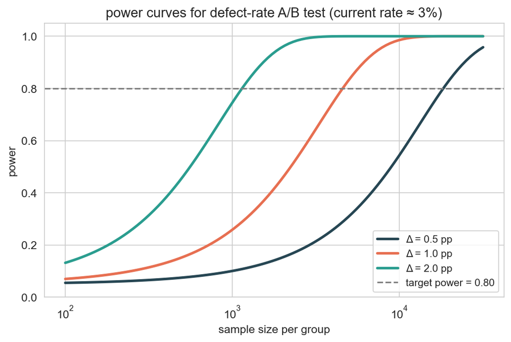

1. From the plot, what’s the smallest sample size per group that achieves **80% power** if the team assumes a $\Delta = 1.0$ percentage-point reduction? ________
2. The factory’s testing budget allows at most $n = 2{,}000$ units per group. From the plot, what is the **smallest defect-rate reduction** they can reliably detect (power $\ge 0.80$) within that budget? Circle one: $\Delta \approx 0.5$ pp / $\Delta \approx 1.0$ pp / $\Delta \approx 2.0$ pp
3. Why does halving the assumed effect size (from $\Delta = 1$ pp to $\Delta = 0.5$ pp) require **more than twice** the sample size to keep power constant? Answer in 1 sentence.

**TipSolution**

**(a)** Reading the orange ($\Delta = 1.0$ pp) curve where it crosses 0.80: $n \approx \mathbf{4{,}500}$ per group (accept any answer in $[3{,}500, 6{,}000]$).

**(b)** **$\Delta \approx 2.0$ pp.** At $n = 2{,}000$ the green curve sits at power $\approx 1.0$, the orange curve sits at power $\approx 0.5$ (well below 80%), and the dark blue curve hasn’t even started rising. Only $\Delta = 2.0$ pp is reliably detectable at this budget.

**(c)** Required $n$ scales like $1/\Delta^2$ (because the standard error shrinks like $1/\sqrt{n}$, and power depends on the *standardized* effect $\Delta/\text{SE}$). Halving $\Delta$ requires roughly **4×** the sample size, not 2×.

**Question 3.** A spam filter classifies each incoming email by computing a “spam score.” If the score exceeds a threshold, the email is flagged as spam; otherwise it goes to the inbox. Frame this as a hypothesis test where $H_0$: the email is legitimate. The figure below shows the score distributions for legitimate emails (under $H_0$) and spam emails (under $H_1$), with the current threshold marked.

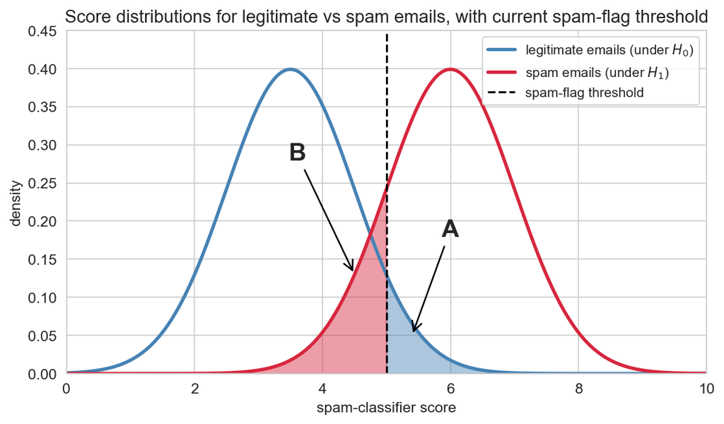

1. Identify each shaded region. Region **A** is the (circle one): **Type I error rate ($\alpha$)** / **Type II error rate ($\beta$)**. Region **B** is the (circle one): **Type I error rate ($\alpha$)** / **Type II error rate ($\beta$)**. In 1 sentence, state in plain language what the Type I error means here (which kind of email ends up in which folder).
2. The user complains that too many spam emails reach the inbox. The team proposes **lowering the threshold** (so more emails get flagged as spam) — i.e., moving the dashed line **leftward**. Which shaded region **shrinks**? Which **grows**? In 1 sentence, name a real-world cost of the now-larger error.

**TipSolution**

**(a)** Region **A** = **Type I error rate ($\alpha$)**: legitimate emails with high enough scores to land past the threshold (right tail of the blue density). Region **B** = **Type II error rate ($\beta$)**: spam emails with low enough scores to fall below the threshold (left tail of the red density).

A **Type I error** here means a legitimate email gets flagged as spam (sent to the spam folder by mistake).

**(b)** Lowering the threshold (moving the dashed line leftward) makes it easier to call something spam — equivalent to easier rejection of $H_0$. **Region B (Type II) shrinks**: fewer spam emails sneak past the threshold into the inbox. **Region A (Type I) grows**: more legitimate emails get incorrectly flagged.

Real-world cost of the now-larger Type I error: users miss important legitimate emails — a job-offer reply, an urgent message from a doctor, a misflagged invoice. The classic $\alpha$-$\beta$ tradeoff: you cannot shrink both error rates at once by moving the threshold alone. To improve both, the team needs a **better-separated classifier** (a different design lever), not just a different threshold.

**Question 4.** A pharmaceutical company screens 1,000 candidate compounds for binding to a target enzyme. For each compound, they run a hypothesis test against a negative control at $\alpha = 0.05$. The histogram of all 1,000 p-values is below.

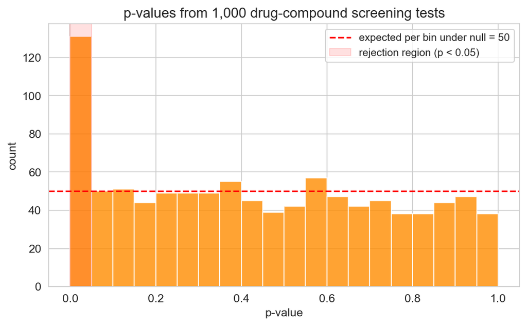

1. If **none** of the 1,000 compounds actually binds (every $H_0$ is true), how many of the 1,000 tests would you expect to come back significant at $\alpha = 0.05$? ________
2. The team observed 131 compounds significant at $\alpha = 0.05$. Is there real signal beyond chance? In 1 sentence, point to the feature of the histogram that supports your answer.
3. Of the 131 observed significant compounds, roughly how many are likely to be **false positives** (chance rejections from null compounds)?
4. The team plans to advance all 131 reported significant compounds to follow-up testing. Approximately what **fraction** of the 131 are likely to be *real binders* (vs. chance rejections from null compounds)? Use your numbers from (a)–(c). In 1 sentence, what does this fraction tell the team about how much follow-up effort will be wasted on noise?

**TipSolution**

**(a)** $1{,}000 \times 0.05 = \mathbf{50}$ false positives expected under the null.

**(b)** **Yes.** The first bin sits at ~131, well above the null floor of ~50/bin shown by the red dashed line. The other 19 bins hover near 50 — exactly the flat baseline expected under uniformity. The spike-near-zero shape is the multi-test signature for “real effects exist.”

**(c)** Roughly **50** (or “about 50/131 ≈ 38% of the observed significant compounds”). Under the null, ~50 false positives would land in the first bin by chance. The remaining ~80 are likely real signals.

**(d)** Likely real binders: $131 - 50 = 81$. Fraction real: $81/131 \approx \mathbf{62\%}$. So roughly **38% of follow-up effort will be wasted** on chance rejections from inactive compounds. If follow-up is cheap (e.g., a quick repeat assay), this rate is acceptable; if follow-up is expensive (animal studies, weeks of bench work), the team should apply a stricter threshold first to reduce the noise fraction. *(This is the same fraction-of-discoveries-that-are-real reasoning that drives the genome-wide significance threshold of $5 \times 10^{-8}$ — at GWAS scale the prior is so much lower that any “discovery” at $\alpha = 0.05$ would be almost entirely noise.)*

**Question 5.** A marketing team A/B tests **80 different email subject lines** for click-through rate. They want to control the family-wise error rate at $\alpha = 0.05$ — that is, ensure at most a 5% chance of *any* false positive across the 80 tests.

1. What is the **Bonferroni threshold** the team should use? ________
2. Without computation: only subject lines with **what kind of effect-size signature** survive this threshold? Circle one and justify in 1 sentence: very strong effects only / moderate-or-larger effects / any effect with $p < 0.05$

**TipSolution**

**(a)** $\alpha_{\text{Bonf}} = \alpha / m = 0.05 / 80 = \mathbf{6.25 \times 10^{-4}}$ (about $0.000625$, or 80× stricter than 0.05).

**(b)** **Very strong effects only.** A p-value of $6 \times 10^{-4}$ corresponds to a t-statistic of about 3.4 — substantially larger than the 1.96 needed at $\alpha = 0.05$. Subject lines with moderate effects ($p$ in the 0.001 to 0.05 range) get filtered out by Bonferroni even when their effects are real. *(That conservative loss is the cost of FWER control; if the team can tolerate a fraction of false discoveries, BH would catch more of the moderate effects.)*

**Question 6.** Pick **Bonferroni** or **Benjamini-Hochberg (BH)** for each scenario, and justify in 1 sentence.

1. An aircraft manufacturer tests 20 candidate alloy compositions for a critical wing component. Any approval of an unsafe alloy could cause a fatal accident.
2. A genomics lab screens 5,000 candidate gene variants for follow-up *experimental* validation in a wet lab. The wet lab can run any number of follow-ups, and the lab leader expects most flagged variants to fail in follow-up.
3. A government agency audits 200 contractors for fraud. A false accusation of fraud creates legal liability and damages the contractor’s reputation.

**TipSolution**

**(a)** **Bonferroni.** Any false positive (approving an unsafe alloy) is catastrophic — we want to control the probability of *any* error, even at the cost of missing some safe alloys. FWER control is the right framing.

**(b)** **BH.** The lab is willing to follow up on candidates and weed out false positives experimentally, so a controlled fraction of false discoveries is acceptable. BH catches more real signals than Bonferroni when individual p-values are moderate (Hedenfalk-style).

**(c)** **Bonferroni** is the safer default. Each false accusation has a real, severe cost (legal liability, reputation damage). Treat any false positive as costly — control FWER. *(This is the “drug safety / criminal trial” pattern from the chapter.)*

*Acceptable alternative for partial credit:* a student who argues for **BH** on a “screen-then-investigate” framing — flag a candidate set with controlled FDR, then internally investigate each before issuing any public accusation — has identified a defensible workflow. The key judgment is that *the public accusation* must be FWER-controlled, not necessarily the *initial flag*; arguing this distinction explicitly earns full credit too.

**Question 7.** Two surgeons report their success rates by case difficulty. The figure below shows simple cases, complex cases, and the aggregate (all cases) for both surgeons; sample sizes are marked.

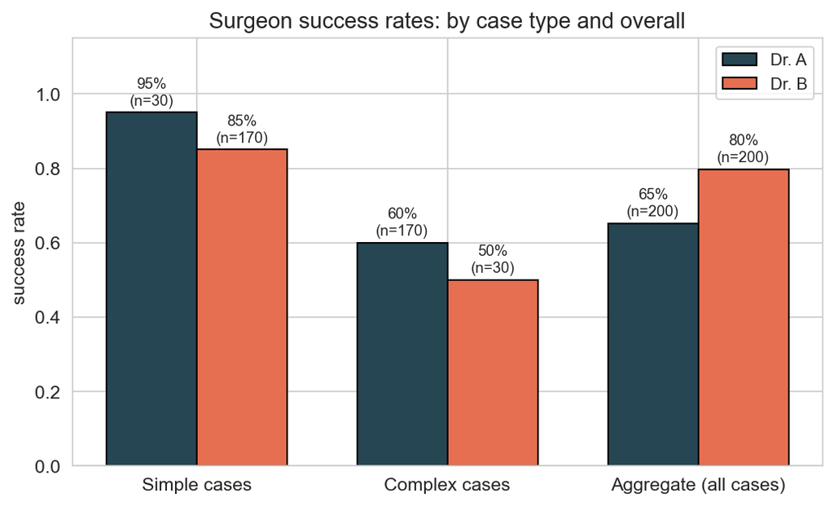

1. If you needed a **complex** procedure, which surgeon would you choose? Justify in 1 sentence.
2. The hospital’s annual report shows only the **aggregate** success rates. Which surgeon would the report flag as the “better” surgeon? In 1–2 sentences, name the statistical phenomenon at play and explain what’s driving the aggregate-vs-subgroup reversal.

**TipSolution**

**(a)** **Dr. A.** Dr. A’s complex-case success rate is 60% (vs 50% for Dr. B). For a patient choosing a surgeon for a complex procedure, the within-subgroup rate is the relevant number — that’s the population they belong to.

**(b)** The aggregate report would flag **Dr. B** as the better surgeon (80% overall vs 65% for Dr. A). This is **Simpson’s paradox**: aggregate rates can reverse the within-subgroup story. The driver is the **case mix** — Dr. B handles mostly simple cases (170 of 200), where success rates are naturally higher, while Dr. A is given mostly complex cases (170 of 200). Dr. B’s higher aggregate just reflects easier cases, not better skill. Case difficulty is a **confounder**: it drives both the input (which surgeon gets the case) and the outcome (success rate), so the aggregate comparison answers the wrong question.

**Question 8.** A health blog reports: *“Counties with more Whole Foods locations per capita have 18% lower rates of heart disease ($r = -0.42$). Conclusion: shopping at Whole Foods prevents heart disease.”*

1. Name **two distinct confounders** that could produce this correlation without organic groceries causing anything.
2. The correlation is computed at the **county** level (one point per county), not the individual level. Why might the *individual-level* correlation between organic shopping and heart disease be much weaker than $r = -0.42$? Name the term for this phenomenon (1 sentence).
3. The blog later updates: *“We tested 50 different supermarket chains; only Whole Foods showed a significant correlation with reduced heart disease. The result survives Bonferroni correction at $\alpha = 0.05$. This proves the effect is real.”* Does Bonferroni-survival establish that Whole Foods *causes* lower heart disease? Answer in 1–2 sentences explaining what Bonferroni does and does not control.

**TipSolution**

**(a)** Any two of:

- **Income / wealth.** Whole Foods locates in high-income areas; high-income individuals have better healthcare access, healthier diets, more exercise time, lower smoking rates. Income drives both Whole Foods presence and heart disease.
- **Education level.** Higher education predicts both organic-food preference and heart-protective behaviors.
- **Age distribution.** Whole Foods may avoid retirement-heavy areas; younger populations have lower baseline heart disease.
- **Urban vs rural.** Whole Foods locates in dense urban areas; urban populations differ from rural ones on many health-relevant dimensions (air quality, walkability, healthcare access).

**(b)** **Ecological correlation fallacy.** Correlations on group averages (one point per county) can be much stronger than correlations on individuals — averaging within counties hides within-county variation, so the strong county-level $r$ may correspond to a much weaker (or null) person-level correlation.

**(c)** **No.** Bonferroni controls the chance of finding *false* correlations among many tests — a guarantee against false positives produced by chance alone. It does **not** address **confounding**: the income/education/urban-rural variables flagged in (a) can produce a correlation between Whole Foods and heart disease that survives any multiple-testing correction, because the correlation is real (not chance), but its *cause* is the confounders, not the groceries. Multiple-testing corrections protect against discovering effects that aren’t there; they cannot protect against discovering effects that are there but reflect the wrong mechanism.

**Question 9.** An education researcher **pre-registers** 12th-grade math test scores as the primary outcome of a school-wide reading-curriculum trial. After the trial, the result for the primary outcome is $p = 0.31$. She then explores 50 secondary analyses (different subgroups, subjects, and outcome measures) and reports: *“The new curriculum significantly improved 8th-grade reading scores in low-income districts ($p = 0.04$). The curriculum works.”*

1. The press release for the trial reads: *“Curriculum failed: no benefit found.”* Why is this an overstatement of the primary result? Reference the difference between **“fail to reject”** and **“accept.”** (1–2 sentences)
2. Why is the secondary finding ($p = 0.04$ in low-income 8th-grade reading) misleading? Name the practice and explain in 1–2 sentences what would have prevented it.

**TipSolution**

**(a)** Failing to reject $H_0$ at $p = 0.31$ does **not** mean “the curriculum has no effect.” It means the data we collected are *compatible* with $H_0$, but they are also compatible with many small (or even moderate) real effects we lacked the power to detect. **Absence of evidence is not evidence of absence.** A more accurate press release: “the trial did not find evidence of an effect on the primary outcome at the planned sample size.”

**(b)** This is **p-hacking** (also called **data dredging** or exploiting **researcher degrees of freedom**) — running many tests and reporting only the survivor that crossed $p < 0.05$. With 50 secondary tests at $\alpha = 0.05$, we’d expect $\sim 2.5$ false positives by chance even if the curriculum has no effect anywhere. The reported $p = 0.04$ is the survivor of hidden multiplicity, not a confirmed finding. **Pre-registration of the secondary outcomes** would have prevented it: any secondary outcome the researcher cared about should have been listed up-front, with a multiple-testing correction applied. Findings from the unplanned 50-outcome exploration should be labeled **exploratory** and treated as hypotheses for a future confirmatory trial — not as discoveries.

**Question 10.** A mobile app team runs an A/B test for a new UI tweak with $n = 500{,}000$ users per arm. Results:

- Control mean session duration: 8.20 min
- Treatment mean session duration: 8.22 min
- 95% CI for the difference: **[+0.01, +0.03] minutes**
- p-value: **< 0.001**

The product manager declares: *“Statistically significant — ship it!”*

1. Without computing anything, what does the 95% CI tell you about the verdict of a two-sided hypothesis test of $H_0: \mu_T - \mu_C = 0$ at $\alpha = 0.05$? Justify in 1 sentence using the CI/test duality.
2. Despite the tiny p-value, give **one reason** you might recommend NOT shipping this UI change. What is the term for the failure mode the PM is exhibiting?

**TipSolution**

**(a)** The 95% CI **excludes 0**, so by **CI/test duality** the two-sided test rejects $H_0$ at $\alpha = 0.05$. (Equivalently: the duality says the 95% CI is exactly the set of null values that the test would *fail* to reject; since 0 is not in that set, the test rejects.)

**(b)** Reasons (any one earns full credit):

- **The effect is tiny** — 0.02 minutes is 1.2 seconds on an 8-minute session, about 0.25%. Users will not notice this. The cost of shipping (engineering, maintenance, A/B-test pipeline real estate) likely outweighs a 1.2-second benefit.
- **With $n = 500{,}000$ per arm, the test has so much power that any nonzero effect — including effects too small to matter — becomes “significant.”** A small p-value here is consistent with a clinically meaningless effect.
- **Opportunity cost** — the engineering effort could be spent on a change that produces a meaningful effect.

Failure mode: **confusing statistical significance with practical importance.** A small p-value tells you the effect is unlikely to be exactly zero. It does *not* tell you the effect is large enough to matter. **Always report the effect size and CI alongside the p-value** so the reader can judge practical importance — not just whether the effect is distinguishable from zero.